# Assignment 4: Topic Analysis (LDA)

Lucian Scher

2026-05-12

## Introduction

This notebook applies latent Dirichlet allocation (LDA) to LexisNexis news articles on **artificial intelligence and conservation**. The goal is to discover latent themes, choose a defensible number of topics `k`, and interpret the resulting topics.

```r
library(LexisNexisTools)
library(here)
library(quanteda)
library(topicmodels)
library(topicdoc)
library(ldatuning)
library(tidyverse)
library(tidytext)
library(reshape2)
library(tictoc)
library(LDAvis)
library(tsne)
```

## 1. Build and clean your corpus

```r
nexis_dir <- here::here("Nexis", "AI_conservation")

pre_files <- list.files(
  path = nexis_dir,
  pattern = "\\.docx$",
  full.names = TRUE,
  recursive = TRUE,
  ignore.case = TRUE
)

pre_dat <- lnt_read(pre_files)

pre_meta_df     <- pre_dat@meta
pre_articles_df <- pre_dat@articles
pre_paragraphs_df <- pre_dat@paragraphs

df <- tibble(
  date     = pre_meta_df$Date,
  headline = pre_meta_df$Headline,
  id       = pre_meta_df$ID,
  text     = pre_articles_df$Article,
  source   = pre_meta_df$Newspaper
) |>
  filter(!is.na(text), nzchar(trimws(text)))

nrow(df)
```

```
## [1] 96
```

```r
corp <- corpus(df, docid_field = "id", text_field = "text")

add_stops <- c(
  quanteda::stopwords("en", source = "smart"),
  "said", "says", "say", "told", "according",
  "vol", "document", "fig", "pg", "usepackage",
  "system", "systems",
  "ai", "artificial", "intelligence",
  "conservation", "conserving",
  "1", "=", "$", "0"
)

toks <- tokens(corp, remove_punct = TRUE, remove_numbers = TRUE) |>
  tokens_tolower() |>
  tokens_remove(pattern = add_stops)

dfm_raw <- dfm(toks)
dfm_prep <- dfm_trim(dfm_raw, min_docfreq = 2)
dfm <- dfm_prep[quanteda::ntoken(dfm_prep) > 0, ]

quanteda::ndoc(dfm)
```

```
## [1] 96
```

```r
quanteda::nfeat(dfm)
```

```
## [1] 11576
```

```r
dtm_tm <- quanteda::convert(dfm, to = "topicmodels")
```

## 2. Select k using multiple criteria

### 2a. Coherence (topicdoc)

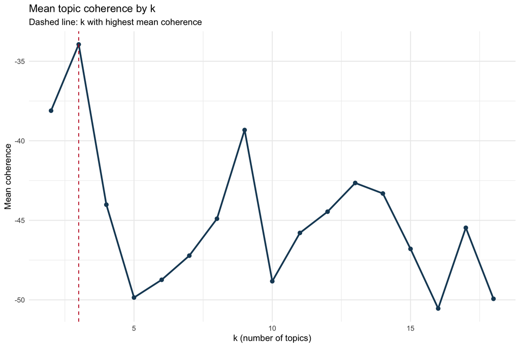

```r
tic()
k_hi <- min(18L, max(2L, quanteda::ndoc(dfm) - 1L))
k_vals <- seq.int(from = 2L, to = k_hi)

coherence_tbl <- map_dfr(k_vals, \(k) {
  m <- LDA(
    dtm_tm,
    k = k,
    method = "Gibbs",
    control = list(iter = 250, verbose = 0, seed = 321)
  )
  coh <- topic_coherence(m, dfm)
  tibble(k = k, topic = seq_len(k), coherence = as.numeric(coh))
})

coherence_summary <- coherence_tbl |>
  group_by(k) |>
  summarise(mean_coherence = mean(coherence, na.rm = TRUE), .groups = "drop")

k_coherence <- coherence_summary$k[which.max(coherence_summary$mean_coherence)]

ggplot(coherence_summary, aes(k, mean_coherence)) +
  geom_line(color = "#1B4965", linewidth = 1) +
  geom_point(color = "#1B4965", size = 2) +
  geom_vline(xintercept = k_coherence, linetype = "dashed", color = "#C1121F") +
  labs(
    title = "Mean topic coherence by k",
    subtitle = "Dashed line: k with highest mean coherence",
    x = "k (number of topics)",
    y = "Mean coherence"
  ) +
  theme_minimal()
```

```r
toc()
```

```
## 49.644 sec elapsed
```

### 2b. FindTopicsNumber() optimization metrics (ldatuning)

```r
tic()
ftn <- FindTopicsNumber(
  dtm_tm,
  topics = 2:16,
  metrics = c("CaoJuan2009", "Arun2010", "Deveaud2014"),
  method = "Gibbs",
  control = list(seed = 321, verbose = 0, burnin = 1000, iter = 2000, keep = 0),
  mc.cores = 1L
)
toc()
```

```
## 518.951 sec elapsed
```

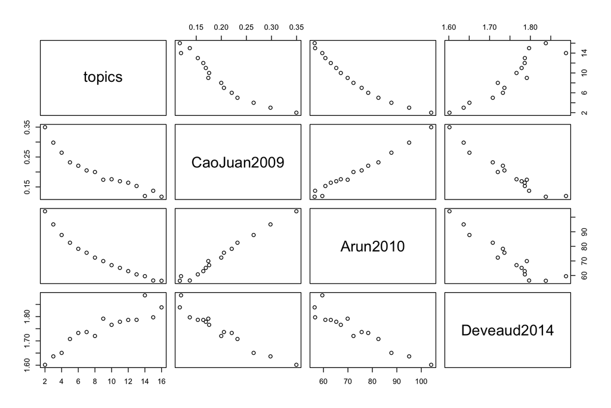

```r
plot(ftn)
```

```r
ks <- ftn$topics

k_cao     <- ks[which.min(ftn$CaoJuan2009)]
k_arun    <- ks[which.min(ftn$Arun2010)]
k_deveaud <- ks[which.max(ftn$Deveaud2014)]

tibble(
  metric = c("CaoJuan2009 (min)", "Arun2010 (min)", "Deveaud2014 (max)"),
  suggested_k = c(k_cao, k_arun, k_deveaud)
)
```

```
## # A tibble: 3 × 2
##   metric            suggested_k
##   <chr>                   <int>
## 1 CaoJuan2009 (min)          16
## 2 Arun2010 (min)             16
## 3 Deveaud2014 (max)          14
```

### 2c. Three explicit candidate models (3 k values)

```r
candidate_ks <- sort(unique(c(
  k_coherence,
  max(2, k_coherence - 3),
  round(median(c(k_cao, k_arun, k_deveaud), na.rm = TRUE))
)))[1:3]

models_3 <- setNames(
  lapply(candidate_ks, \(k) LDA(
    dtm_tm, k = k, method = "Gibbs",
    control = list(iter = 800, verbose = 0, seed = 321)
  )),
  candidate_ks
)
```

```r
k <- k_coherence
k
```

```
## [1] 3
```

## 3. Fit your final model and visualize top terms

```r
topicModel_final <- LDA(
  dtm_tm,
  k = k,
  method = "Gibbs",
  control = list(iter = 2000, verbose = 50, seed = 321)
)
```

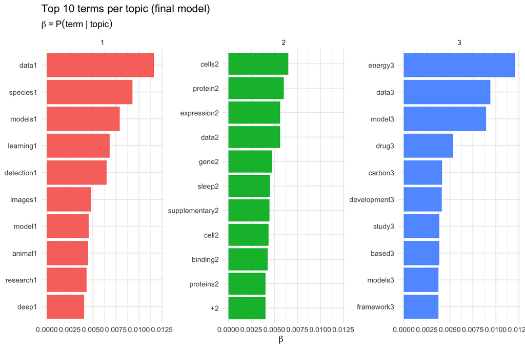

```r
tmResult <- posterior(topicModel_final)
theta_mat <- tmResult$topics

topics_beta <- tidy(topicModel_final, matrix = "beta")

top_terms <- topics_beta |>
  group_by(topic) |>
  slice_max(beta, n = 10) |>
  ungroup() |>
  mutate(topic = factor(topic))

top_terms |>
  mutate(term = tidytext::reorder_within(term, beta, topic, sep = "")) |>
  ggplot(aes(term, beta, fill = topic)) +
  geom_col(show.legend = FALSE) +
  facet_wrap(~ topic, scales = "free_y") +
  tidytext::scale_x_reordered() +
  coord_flip() +
  labs(
    title = "Top 10 terms per topic (final model)",
    subtitle = expression(beta ~ "=" ~ P(term ~ "|" ~ topic)),
    x = NULL,
    y = expression(beta)
  ) +
  theme_minimal()
```

## 4. Visualize document-topic distributions (θ)

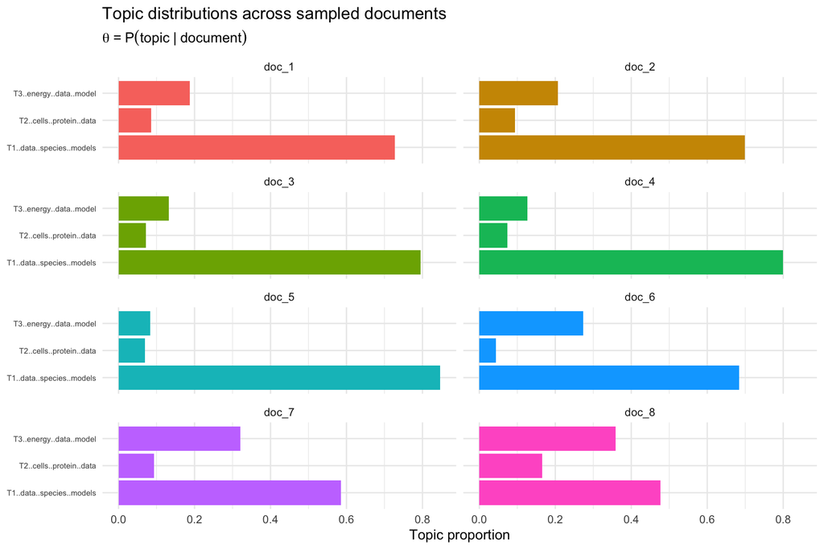

```r
set.seed(10)
sample_n <- min(8L, nrow(theta_mat))

doc_idx <- seq_len(sample_n)
props <- theta_mat[doc_idx, , drop = FALSE]

tw10 <- terms(topicModel_final, 10)
stub_names <- apply(tw10, 2, \(col) paste(utils::head(col, 3), collapse = ", "))
colnames(props) <- paste0("T", seq_len(ncol(props)), ": ", stub_names)

viz_df <- reshape2::melt(
  cbind(data.frame(props), document = factor(doc_idx, labels = paste0("doc_", doc_idx))),
  variable.name = "topic_stub",
  id.vars = "document"
)

ggplot(viz_df, aes(topic_stub, value, fill = document)) +
  geom_col(show.legend = FALSE) +
  coord_flip() +
  facet_wrap(~ document, ncol = 2L) +
  theme_minimal() +
  theme(axis.text.y = element_text(size = rel(0.7))) +
  labs(
    title = "Topic distributions across sampled documents",
    subtitle = expression(theta ~ "=" ~ P(topic ~ "|" ~ document)),
    x = NULL,
    y = "Topic proportion"
  )
```

## 5. LDAvis

```r
svd_tsne <- function(x) tsne(svd(x)$u)

json <- createJSON(
  phi            = tmResult$terms,
  theta          = tmResult$topics,
  doc.length     = rowSums(dfm),
  vocab          = colnames(dfm),
  term.frequency = colSums(dfm),
  mds.method     = svd_tsne,
  plot.opts      = list(xlab = "", ylab = "")
)

serVis(json)
```

## 6. Interpret your topics

```r
topic_terms <- terms(topicModel_final, 10)

topic_names <- c(
  "Policy and Large-scale applications",
  "Wildlife preservation and monitoring",
  "Science and research"
)

topic_table <- as_tibble(topic_terms, .name_repair = "minimal")
colnames(topic_table) <- topic_names

topic_table
```

```
## # A tibble: 10 × 3
##    Policy and Large-scale applic…¹ Wildlife preservatio…² `Science and research`
##    <chr>                           <chr>                  <chr>
##  1 data                            cells                  energy
##  2 species                         protein                data
##  3 models                          data                   model
##  4 learning                        expression             drug
##  5 detection                       gene                   carbon
##  6 images                          sleep                  development
##  7 model                           supplementary          study
##  8 animal                          cell                   based
##  9 research                        binding                models
## 10 deep                            +                      framework
## # ℹ abbreviated names: ¹`Policy and Large-scale applications`,
## #   ²`Wildlife preservation and monitoring`
```

### Interpretation

*Policy and Large-scale applications* This topic is about scaling AI tools for policy and operational decision-making, especially using big datasets and predictive modeling. The most diagnostic words are data, models/model, learning, detection, and deep. Several ambiguous terms (species, animal, images) sound like ecology/computer vision and may overlap with monitoring rather than pure policy.

*Wildlife preservation and monitoring* This topic appears to be computational biology / lab-style monitoring language (cell and gene processes) rather than wildlife conservation in the usual sense. The most diagnostic words are cells/cell, protein, expression, gene, and binding. Surprising/ambiguous terms include sleep and the symbol “+”, which look like extraction noise rather than a clear theme.

*Science and research* This topic reads as research-and-development framing around scientific applications, including energy/climate-related work and technical modeling. The most diagnostic words are energy, carbon, development, study, and models/model/framework. The ambiguous word is drug, which suggests some articles in the corpus are biomedical and may be pulling the topic away from conservation-specific science.